# SPSS_Output_hmwk4key

[output not shown]

Log  
Log - Log - November 1, 2018

GET  
FILE='C:\MyGithub\N736Fall2017_Homework4Key\helpmkh.sav'.  
DATASET NAME DataSet1 WINDOW=FRONT.  
* Encoding: UTF-8.  
* ==========================================.  
* N736 HOMEWORK 04 - Answer Key  
*  
* by Melinda Higgins, PhD  
* updated 10/31/2018  
* ==========================================.  
REGRESSION  
/DESCRIPTIVES MEAN STDDEV CORR SIG N  
/MISSING LISTWISE  
/STATISTICS COEFF OUTS CI(95) R ANOVA COLLIN TOL CHANGE ZPP  
/CRITERIA=PIN(.05) POUT(.10)  
/NOORIGIN  
/DEPENDENT cesd  
/METHOD=ENTER indtot  
/RESIDUALS DURBIN HISTOGRAM(ZRESID) NORMPROB(ZRESID)  
/CASEWISE PLOT(ZRESID) OUTLIERS(3)  
/SAVE PRED ZPRED COOK RESID ZRESID.

Regression  
Regression - Active Dataset - November 1, 2018

[DataSet1] C:\MyGithub\N736Fall2017_Homework4Key\helpmkh.sav

Regression  
Regression - Descriptive Statistics - November 1, 2018

Descriptive StatisticsDescriptive Statistics, table, 1 levels of column headers and 1 levels of row headers, table with 4 columns and 4 rows

|  | Mean | Std. Deviation | N |
| --- | --- | --- | --- |
| cesd CESD total score - Baseline | 32.85 | 12.514 | 453 |
| indtot Inventory of Drug Use Consequences (InDue) total score - Baseline | 35.73 | 7.152 | 453 |

Regression  
Regression - Correlations - November 1, 2018

CorrelationsCorrelations, table, 1 levels of column headers and 2 levels of row headers, table with 4 columns and 8 rows

|  |  | cesd CESD total score - Baseline | indtot Inventory of Drug Use Consequences (InDue) total score - Baseline |
| --- | --- | --- | --- |
| Pearson Correlation | cesd CESD total score - Baseline | 1.000 | .336 |
|  | indtot Inventory of Drug Use Consequences (InDue) total score - Baseline | .336 | 1.000 |
| Sig. (1-tailed) | cesd CESD total score - Baseline | . | .000 |
|  | indtot Inventory of Drug Use Consequences (InDue) total score - Baseline | .000 | . |
| N | cesd CESD total score - Baseline | 453 | 453 |
|  | indtot Inventory of Drug Use Consequences (InDue) total score - Baseline | 453 | 453 |

Regression  
Regression - Variables Entered/Removed - November 1, 2018

Variables Entered/Removed<sup>a</sup>Variables Entered/Removed, table, 1 levels of column headers and 1 levels of row headers, table with 4 columns and 5 rows

| Model | Variables Entered | Variables Removed | Method |
| --- | --- | --- | --- |
| 1 | indtot Inventory of Drug Use Consequences (InDue) total score - Baseline<sup>b</sup> | . | Enter |

a. Dependent Variable: cesd CESD total score - Baseline  
b. All requested variables entered.

Regression  
Regression - Model Summary - November 1, 2018

Model Summary<sup>b</sup>Model Summary, table, 2 levels of column headers and 1 levels of row headers, table with 11 columns and 6 rows

| Model | R | R Square | Adjusted R Square | Std. Error of the Estimate | Change Statistics |  |  |  |  | Durbin-Watson |  |
| --- | --- | --- | --- | --- | --- | --- | --- | --- | --- | --- | --- |
|  |  |  |  |  | R Square Change | F Change | df1 | df2 | Sig. F Change |  |  |
| 1 | .336<sup>a</sup> | .113 | .111 | 11.802 | .113 | 57.251 | 1 | 451 | .000 |  | 1.785 |

a. Predictors: (Constant), indtot Inventory of Drug Use Consequences (InDue) total score - Baseline  
b. Dependent Variable: cesd CESD total score - Baseline

Regression  
Regression - ANOVA - November 1, 2018

ANOVA<sup>a</sup>ANOVA, table, 1 levels of column headers and 2 levels of row headers, table with 7 columns and 7 rows

| Model |  | Sum of Squares | df | Mean Square | F | Sig. |
| --- | --- | --- | --- | --- | --- | --- |
| 1 | Regression | 7973.897 | 1 | 7973.897 | 57.251 | .000<sup>b</sup> |
|  | Residual | 62814.593 | 451 | 139.278 |  |  |
|  | Total | 70788.490 | 452 |  |  |  |

a. Dependent Variable: cesd CESD total score - Baseline  
b. Predictors: (Constant), indtot Inventory of Drug Use Consequences (InDue) total score - Baseline

Regression  
Regression - Coefficients - November 1, 2018

Coefficients<sup>a</sup>Coefficients, table, 2 levels of column headers and 2 levels of row headers, table with 14 columns and 6 rows

| Model |  | Unstandardized Coefficients |  | Standardized Coefficients | t | Sig. | 95.0% Confidence Interval for B |  | Correlations |  |  | Collinearity Statistics |  |
| --- | --- | --- | --- | --- | --- | --- | --- | --- | --- | --- | --- | --- | --- |
|  |  | B | Std. Error | Beta |  |  | Lower Bound | Upper Bound | Zero-order | Partial | Part | Tolerance | VIF |
| 1 | (Constant) | 11.866 | 2.828 |  | 4.196 | .000 | 6.309 | 17.423 |  |  |  |  |  |
|  | indtot Inventory of Drug Use Consequences (InDue) total score - Baseline | .587 | .078 | .336 | 7.566 | .000 | .435 | .740 | .336 | .336 | .336 | 1.000 | 1.000 |

a. Dependent Variable: cesd CESD total score - Baseline

Regression  
Regression - Collinearity Diagnostics - November 1, 2018

Collinearity Diagnostics<sup>a</sup>Collinearity Diagnostics, table, 2 levels of column headers and 2 levels of row headers, table with 6 columns and 6 rows

| Model | Dimension | Eigenvalue | Condition Index | Variance Proportions |  |
| --- | --- | --- | --- | --- | --- |
|  |  |  |  | (Constant) | indtot Inventory of Drug Use Consequences (InDue) total score - Baseline |
| 1 | 1 | 1.981 | 1.000 | .01 | .01 |
|  | 2 | .019 | 10.101 | .99 | .99 |

a. Dependent Variable: cesd CESD total score - Baseline

Regression  
Regression - Residuals Statistics - November 1, 2018

Residuals Statistics<sup>a</sup>Residuals Statistics, table, 1 levels of column headers and 1 levels of row headers, table with 6 columns and 15 rows

|  | Minimum | Maximum | Mean | Std. Deviation | N |
| --- | --- | --- | --- | --- | --- |
| Predicted Value | 14.21 | 38.29 | 32.85 | 4.200 | 453 |
| Std. Predicted Value | -4.436 | 1.296 | .000 | 1.000 | 453 |
| Standard Error of Predicted Value | .555 | 2.524 | .736 | .270 | 453 |
| Adjusted Predicted Value | 13.31 | 38.42 | 32.85 | 4.210 | 453 |
| Residual | -34.356 | 30.674 | .000 | 11.789 | 453 |
| Std. Residual | -2.911 | 2.599 | .000 | .999 | 453 |
| Stud. Residual | -2.916 | 2.637 | .000 | 1.001 | 453 |
| Deleted Residual | -34.459 | 31.579 | .002 | 11.847 | 453 |
| Stud. Deleted Residual | -2.940 | 2.655 | .000 | 1.003 | 453 |
| Mahal. Distance | .001 | 19.680 | .998 | 2.178 | 453 |
| Cook's Distance | .000 | .103 | .002 | .007 | 453 |
| Centered Leverage Value | .000 | .044 | .002 | .005 | 453 |

a. Dependent Variable: cesd CESD total score - Baseline

Charts  
Charts - *zresid Histogram - November 1, 2018

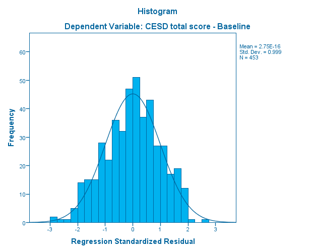

Charts  
Charts - *zresid Normal P-P Plot - November 1, 2018

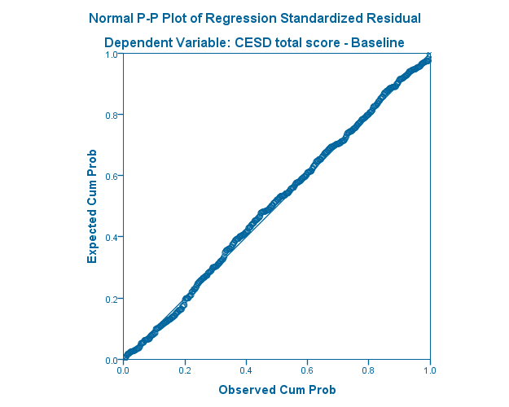

Log  
Log - Log - November 1, 2018

GRAPH  
/SCATTERPLOT(BIVAR)=ZPR_1 WITH ZRE_1  
/MISSING=LISTWISE.

Graph  
Graph - Scatter of ZRE_1 ZPR_1 - November 1, 2018

[figure not shown]

Log  
Log - Log - November 1, 2018

GRAPH  
/SCATTERPLOT(BIVAR)=id WITH COO_1  
/MISSING=LISTWISE.

Graph  
Graph - Scatter of COO_1 id - November 1, 2018

[figure not shown]

Log  
Log - Log - November 1, 2018

GRAPH  
/SCATTERPLOT(BIVAR)=id WITH ZRE_1  
/MISSING=LISTWISE.

Graph  
Graph - Scatter of ZRE_1 id - November 1, 2018

[figure not shown]

Log  
Log - Log - November 1, 2018

GRAPH  
/SCATTERPLOT(BIVAR)=indtot WITH cesd  
/MISSING=LISTWISE.

Graph  
Graph - Scatter of cesd indtot - November 1, 2018

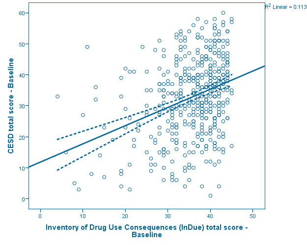

Log  
Log - Log - November 1, 2018

SORT CASES BY id (A).  
GRAPH  
/SCATTERPLOT(BIVAR)=id WITH cesd  
/MISSING=LISTWISE.

Graph  
Graph - Scatter of cesd id - November 1, 2018

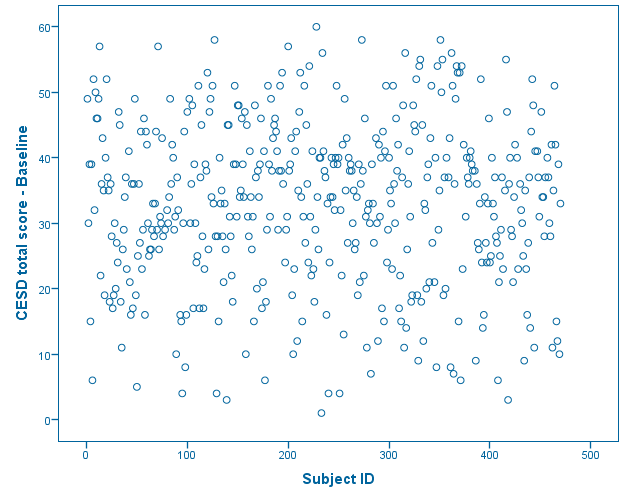

Log  
Log - Log - November 1, 2018

GRAPH  
/SCATTERPLOT(BIVAR)=id WITH indtot  
/MISSING=LISTWISE.

Graph  
Graph - Scatter of indtot id - November 1, 2018

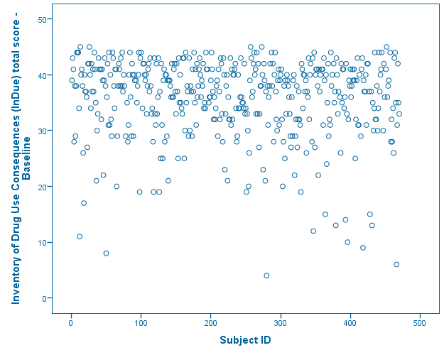

Log  
Log - Log - November 1, 2018

* recode character race into numeric coded variable.  
AUTORECODE VARIABLES=racegrp  
/INTO racenum  
/PRINT.  
>Error # 17006  
>An already existing variable name was used on the INTO subcommand.  
>Execution of this command stops.  
UNIANOVA cesd BY racenum  
/METHOD=SSTYPE(3)  
/INTERCEPT=INCLUDE  
/POSTHOC=racenum(SIDAK)  
/EMMEANS=TABLES(OVERALL)  
/EMMEANS=TABLES(racenum)  
/PRINT=ETASQ HOMOGENEITY DESCRIPTIVE  
/CRITERIA=ALPHA(.05)  
/DESIGN=racenum.

Univariate Analysis of Variance  
Univariate Analysis of Variance - Between-Subjects Factors - November 1, 2018

Between-Subjects FactorsBetween-Subjects Factors, table, 1 levels of column headers and 2 levels of row headers, table with 4 columns and 6 rows

|  |  | Value Label | N |
| --- | --- | --- | --- |
| racenum Racial Group of Respondent | 1 | black | 211 |
|  | 2 | hispanic | 50 |
|  | 3 | other | 26 |
|  | 4 | white | 166 |

Univariate Analysis of Variance  
Univariate Analysis of Variance - Descriptive Statistics - November 1, 2018

Descriptive StatisticsDescriptive Statistics, table, Dependent Variable, cesd CESD total score - Baseline, 1 layers, 1 levels of column headers and 1 levels of row headers, table with 4 columns and 8 rows

| cesd CESD total score - Baseline cesd CESD total score - Baseline |  |  |  |
| --- | --- | --- | --- |
| racenum Racial Group of Respondent | Mean | Std. Deviation | N |
| 1 black | 30.18 | 12.993 | 211 |
| 2 hispanic | 34.36 | 10.717 | 50 |
| 3 other | 35.92 | 12.099 | 26 |
| 4 white | 35.30 | 11.854 | 166 |
| Total | 32.85 | 12.514 | 453 |

Univariate Analysis of Variance  
Univariate Analysis of Variance - Levene's Test of Equality of Error Variances - November 1, 2018

Levene's Test of Equality of Error Variances<sup>a</sup>Levene's Test of Equality of Error Variances, table, Dependent Variable, cesd CESD total score - Baseline, 1 layers, 1 levels of column headers and 0 levels of row headers, table with 4 columns and 6 rows

| cesd CESD total score - Baseline cesd CESD total score - Baseline |  |  |  |
| --- | --- | --- | --- |
| F | df1 | df2 | Sig. |
| .944 | 3 | 449 | .419 |

Tests the null hypothesis that the error variance of the dependent variable is equal across groups.  
a. Design: Intercept + racenum

Univariate Analysis of Variance  
Univariate Analysis of Variance - Tests of Between-Subjects Effects - November 1, 2018

Tests of Between-Subjects EffectsTests of Between-Subjects Effects, table, Dependent Variable, cesd CESD total score - Baseline, 1 layers, 1 levels of column headers and 1 levels of row headers, table with 7 columns and 10 rows

| cesd CESD total score - Baseline cesd CESD total score - Baseline |  |  |  |  |  |  |
| --- | --- | --- | --- | --- | --- | --- |
| Source | Type III Sum of Squares | df | Mean Square | F | Sig. | Partial Eta Squared |
| Corrected Model | 2861.028<sup>a</sup> | 3 | 953.676 | 6.304 | .000 | .040 |
| Intercept | 266261.807 | 1 | 266261.807 | 1759.988 | .000 | .797 |
| racenum | 2861.028 | 3 | 953.676 | 6.304 | .000 | .040 |
| Error | 67927.462 | 449 | 151.286 |  |  |  |
| Total | 559562.000 | 453 |  |  |  |  |
| Corrected Total | 70788.490 | 452 |  |  |  |  |

a. R Squared = .040 (Adjusted R Squared = .034)

Estimated Marginal Means  
Estimated Marginal Means - 1. Grand Mean - November 1, 2018

1. Grand Mean1. Grand Mean, table, Dependent Variable, cesd CESD total score - Baseline, 1 layers, 2 levels of column headers and 0 levels of row headers, table with 4 columns and 5 rows

| cesd CESD total score - Baseline cesd CESD total score - Baseline |  |  |  |
| --- | --- | --- | --- |
| Mean | Std. Error | 95% Confidence Interval |  |
|  |  | Lower Bound | Upper Bound |
| 33.941 | .809 | 32.351 | 35.531 |

Estimated Marginal Means  
Estimated Marginal Means - 2. Racial Group of Respondent - November 1, 2018

2. Racial Group of Respondent2. Racial Group of Respondent, table, Dependent Variable, cesd CESD total score - Baseline, 1 layers, 2 levels of column headers and 1 levels of row headers, table with 5 columns and 8 rows

| cesd CESD total score - Baseline cesd CESD total score - Baseline |  |  |  |  |
| --- | --- | --- | --- | --- |
| Racial Group of Respondent | Mean | Std. Error | 95% Confidence Interval |  |
|  |  |  | Lower Bound | Upper Bound |
| 1 black | 30.180 | .847 | 28.516 | 31.844 |
| 2 hispanic | 34.360 | 1.739 | 30.942 | 37.778 |
| 3 other | 35.923 | 2.412 | 31.182 | 40.664 |
| 4 white | 35.301 | .955 | 33.425 | 37.177 |

Racial Group of Respondent  
Racial Group of Respondent - Multiple Comparisons - November 1, 2018

Multiple ComparisonsMultiple Comparisons, table, Dependent Variable, cesd CESD total score - Baseline, Sidak, 1 layers, 2 levels of column headers and 2 levels of row headers, table with 7 columns and 19 rows

| cesd CESD total score - Baseline cesd CESD total score - Baseline Sidak Sidak |  |  |  |  |  |  |
| --- | --- | --- | --- | --- | --- | --- |
| (I) Racial Group of Respondent | (J) Racial Group of Respondent | Mean Difference (I-J) | Std. Error | Sig. | 95% Confidence Interval |  |
|  |  |  |  |  | Lower Bound | Upper Bound |
| 1 black | 2 hispanic | -4.18 | 1.935 | .173 | -9.29 | .93 |
|  | 3 other | -5.74 | 2.556 | .142 | -12.50 | 1.01 |
|  | 4 white | -5.12* | 1.276 | .000 | -8.49 | -1.75 |
| 2 hispanic | 1 black | 4.18 | 1.935 | .173 | -.93 | 9.29 |
|  | 3 other | -1.56 | 2.974 | .996 | -9.42 | 6.30 |
|  | 4 white | -.94 | 1.984 | .998 | -6.18 | 4.30 |
| 3 other | 1 black | 5.74 | 2.556 | .142 | -1.01 | 12.50 |
|  | 2 hispanic | 1.56 | 2.974 | .996 | -6.30 | 9.42 |
|  | 4 white | .62 | 2.594 | 1.000 | -6.23 | 7.48 |
| 4 white | 1 black | 5.12* | 1.276 | .000 | 1.75 | 8.49 |
|  | 2 hispanic | .94 | 1.984 | .998 | -4.30 | 6.18 |
|  | 3 other | -.62 | 2.594 | 1.000 | -7.48 | 6.23 |

Based on observed means. The error term is Mean Square(Error) = 151.286.  
*. The mean difference is significant at the .05 level.

Log  
Log - Log - November 1, 2018

GRAPH  
/ERRORBAR(CI 95)=cesd BY racenum.

Graph  
Graph - Error Bar of cesd by racenum - November 1, 2018

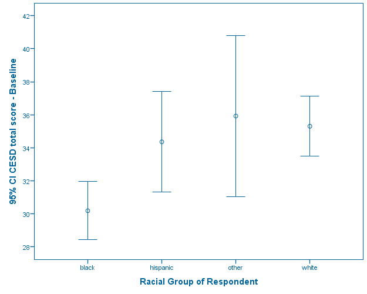

Log  
Log - Log - November 1, 2018

GRAPH  
/ERRORBAR(STDDEV 1)=cesd BY racenum.

Graph  
Graph - Error Bar of cesd by racenum - November 1, 2018

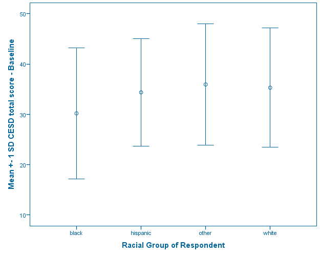

[output not shown]

[output not shown]

[output not shown]

[output not shown]

[output not shown]

[output not shown]

[output not shown]

[output not shown]

[output not shown]